# Lab 2- Data Visualization Basics

### Lab 2 ( Vismay Gehlot)

Submission instructions: Submit your lab work just like HW1 by going to Canvas and then assignments --> Lab Assignments -->Lab 2 and submitting two files (pdf or html and ipynb)

This lab assignment has two parts. The first part is practice which you do with your TA and the second part is the Lab assinment which you do it yourself following the instructions on the first part. There are a total of 5 problems for yout to. Total points ( 50)

Data set: We will work on a titanic data set in this homework. To know more about Titanic ship, story and the tragedy read this https://www.britannica.com/topic/Titanic

Variables used in this data set

survival - Survival (0 = No; 1 = Yes)

class - Passenger Class (1 = 1st; 2 = 2nd; 3 = 3rd)

name - Name

sex - Sex

age - Age

sibsp - Number of Siblings/Spouses Aboard

parch - Number of Parents/Children Aboard

ticket - Ticket Number

fare - Fare passenger paid in pounds.

cabin - Cabin number

embarked - Where passenger boarded the ship (C = Cherbourg; Q = Queenstown; S = Southampton)

boat - Lifeboat (if survived)

body - Body number (if did not survive and body was recovered)

home.dest - Where passenger is going.

Import pandas as pd and load the titanic data and name it as titanic.

```python
# Import all the packages we need and the titanic data
import pandas as pd
import numpy as np
import matplotlib as mpl
import matplotlib.pyplot as mpt
import seaborn as sbn
df = pd.read_csv('titanic.csv')
```

```python
# Let's see what columns do we have?
df.columns
```

```
Index(['pclass', 'survived', 'name', 'sex', 'age', 'sibsp', 'parch', 'ticket',
       'fare', 'cabin', 'embarked', 'boat', 'body', 'home.dest'],
      dtype='object')
```

We will now remove some columns with a lot of missing data. Let's remove 'sibsp', 'parch', 'ticket', 'boat', 'body' and 'home.dest' from the data and create a new data set with remaining columns.

```python
newcols = ['pclass', 'survived', 'name', 'sex', 'age','fare', 'embarked']
newdf = df [newcols]
newdf.columns
```

```
Index(['pclass', 'survived', 'name', 'sex', 'age', 'fare', 'embarked'], dtype='object')
```

It looks like we have all the columns we need. Let's see if there is still any missing values in these columns.

```python
newdf.isna().sum()
```

```
pclass        1
survived      1
name          1
sex           1
age         264
fare          2
embarked      3
dtype: int64
```

There is still some missing entries. Let's remove all the rows with at least one missing entries.

```python
newdf1= newdf.dropna(how ='any')
```

```python
newdf1.shape
```

```
(1043, 7)
```

### From the HW2. We created the following scatterplot.

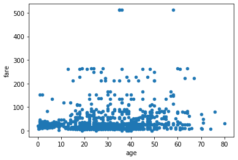

```python
df.plot(kind ='scatter', x= 'age', y= 'fare')
```

```python
newdf2=newdf[newdf.fare>=400]

newdf2.head()
```

|  | pclass | survived | name | sex | age | fare | embarked |
| --- | --- | --- | --- | --- | --- | --- | --- |
| 49 | 1.0 | 1.0 | Cardeza, Mr. Thomas Drake Martinez | male | 36.0 | 512.3292 | C |
| 50 | 1.0 | 1.0 | Cardeza, Mrs. James Warburton Martinez (Charlo... | female | 58.0 | 512.3292 | C |
| 183 | 1.0 | 1.0 | Lesurer, Mr. Gustave J | male | 35.0 | 512.3292 | C |
| 302 | 1.0 | 1.0 | Ward, Miss. Anna | female | 35.0 | 512.3292 | C |

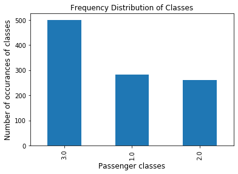

```python
# We will now make a bar plot of the column 'pclass'. As it has three labels, we will get
# Note here that I am naming the graph and also naming x-axis and y-axis my way.
newdf1.pclass.value_counts().plot(kind='bar')
mpt.title('Frequency Distribution of Classes')
mpt.ylabel('Number of occurances of classes', fontsize=12)
mpt.xlabel('Passenger classes', fontsize=12)
```

## Problem 1.

Make a bar plot of the column named 'embarked' and give appropriate title and labels in x and axes. Change the bar plot to horizontal bar plot. For this all you need to do is change the part of the code where it says kind = 'bar' to kind ='barh'. Extra h here means horizontal. You do have to label axes appropriatley. ( 12 points )

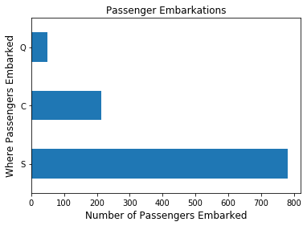

```python
newdf1.embarked.value_counts().plot(kind='barh')
mpt.title('Passenger Embarkations')
mpt.ylabel('Where Passengers Embarked', fontsize=12)
mpt.xlabel('Number of Passengers Embarked', fontsize=12)
```

We will work on a pie chart plot now. Let's plot this passenger class data to make a pie chart.

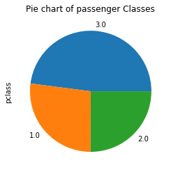

```python
newdf1.pclass.value_counts().plot(kind='pie')
mpt.title('Pie chart of passenger Classes')
```

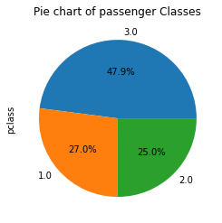

```python
# Here I changed some code to show % numbers inside the pie pieces.
newdf1.pclass.value_counts().plot(kind='pie',autopct='%1.1f%%')
mpt.title('Pie chart of passenger Classes')
```

### Problem 2

Make a pie chart of the column named 'embarked' and label it appropriately. Modify the first line of code to show % numbers inside each pie. ( 12 points)

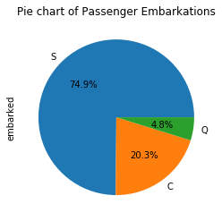

```python
newdf1.embarked.value_counts().plot(kind='pie',autopct='%1.1f%%')
mpt.title('Pie chart of Passenger Embarkations')
```

We can filter data in many ways. One of them is to use greater than or less than sign. Let's find out how many infants( less than or equal to 1 year old) were on board. To do this, we will filter the data with the following code.

```python
# Here I am using newdf1.age <=1 to filter all the people with less than 1 year old and
# Writting this code as newdf1[newdf1.age<=1] means that I am taking all the newdf1 data
#where age is less than 1. I am also naming our new data differently.
df2=newdf1[newdf1.age<=1]
# Let's look at the new data
df2.head()
```

|  | pclass | survived | name | sex | age | fare | embarked |
| --- | --- | --- | --- | --- | --- | --- | --- |
| 1 | 1.0 | 1.0 | Allison, Master. Hudson Trevor | male | 0.9167 | 151.5500 | S |
| 339 | 2.0 | 1.0 | Becker, Master. Richard F | male | 1.0000 | 39.0000 | S |
| 359 | 2.0 | 1.0 | Caldwell, Master. Alden Gates | male | 0.8333 | 29.0000 | S |
| 427 | 2.0 | 1.0 | Hamalainen, Master. Viljo | male | 0.6667 | 14.5000 | S |
| 478 | 2.0 | 1.0 | Laroche, Miss. Louise | female | 1.0000 | 41.5792 | C |

### Problem 3

Make a scatter plot of the data frame df2 with age in x-axis and fare in y-axis. Do you see any relationship between infant's age and the fare? Is there an outlier in this graph? ( 12 points)

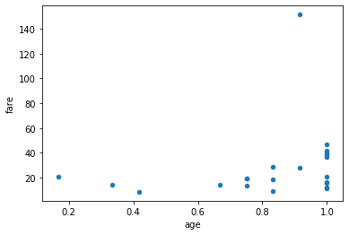

```python
df2.plot(kind ='scatter', x= 'age', y= 'fare')
```

There is a general correlation between age and fare, in that the older the infant is there tends to be a higher ticket fare for that infant. There is one outlier on the top of the graph where the fare for an infant of about 0.9 years is roughly $150 or so. Possible reasons for this can be that the infant was bought a first class ticket, since the family also could have been in first class.

### Problem 4

Type this code df2.fare.plot(style='o-'). This will give a line graph. Please look at the graph and the data df2 and label the axes appropriately. What is plotted in x and y axis. (14 points)

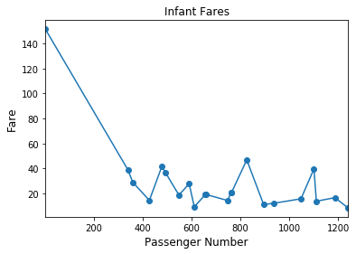

```python
df2.fare.plot(style='o-')
mpt.title('Infant Fares')
mpt.ylabel('Fare', fontsize=12)
mpt.xlabel('Passenger Number', fontsize=12)
```